# scAmbi: Correcting mapping-ambiguity overdispersion in scRNA-seq

Sean T. Bresnahan

2025-08-14

# Processing Alevin bootstraps for Seurat integration

When quantifying single-cell transcript expression, fragment assignment ambiguity and multi-mapping reads can introduce inferential variance in estimated counts. Salmon/Alevin can output per‑cell bootstrap replicates that capture inferential uncertainty due to fragments mapping to multiple transcripts of the same gene<sup>1–3</sup>. This uncertainty manifests as **overdispersion** which, if uncorrected, inflates variability estimates and distorts downstream analyses (differential expression, clustering, trajectory inference)<sup>4</sup>.

Here we present scAmbi, an integrated approach that (i) estimates per‑transcript overdispersion from Alevin bootstraps in a sparse‑aware way, (ii) combines that estimate with moment‑based and annotation‑driven priors for further exploration, and (iii) applies the boostrap-based overdispersion result either by **building a corrected assay** (`RNA_corr`) or by **supplying model offsets**. We then evaluate the impact using **BCV** (biological coefficient of variation) analyses at the between‑sample and within‑sample (cell‑to‑cell) levels.

## How this relates to `edgeR::catchSalmon()`

`catchSalmon` (bulk) computes per‑transcript technical OD from bootstraps across **samples**, applies EB moderation with a floor at 1, and analyzes **scaled** counts. Our approach is analogous but uses **cells** as replicates. Additionally, scAmbi adds a **moment‑based** component, an **annotation prior**, and an **integrated overdispersion estimate** (boostrap + moment-based + annotation prior) for exploration, and supports **offset‑based** workflows in addition to a corrected assay.

## What’s unique about this package

- **OD_integrated**: weighted geometric fusion of three signals: bootstrap‑based OD, moment‑based OD on normalized counts, and a complexity prior from transcript counts per gene, followed by adaptive shrinkage.
- **Sparse‑aware C++ kernel**: blockwise processing of the (transcripts × cells × bootstraps) matrix, strict bounds checking, and efficient dgCMatrix traversal.
- **Flexible correction**: use `RNA_corr` directly, or supply offsets constructed from (a) corrected/raw ratios, (b) OD vectors, or (c) any feature vector stored in `feature_meta`.
- **BCV analysis suite**: between‑sample (pseudobulk across samples) and within‑sample (cell grouping to pseudobulk) pipelines with matched plotting and summaries.

# Dependencies

## Required R packages

This package requires **R version 4.2 or higher**.

### Core dependencies

- **Seurat** (>= 4.0.0): Single-cell data structures and workflows
- **Matrix** (>= 1.3-0): Sparse matrix operations
- **edgeR** (>= 3.34.0): Dispersion estimation and BCV calculations
- **Rcpp** (>= 1.0.7): C++ integration for performance-critical operations

### Data I/O and processing

- **eds** (>= 1.0.0): Reading Alevin EDS sparse matrix format
- **tximport** (>= 1.20.0): Transcript-level quantification import
- **rtracklayer** (>= 1.52.0): GTF file parsing for gene complexity calculations
- **jsonlite** (>= 1.7.0): JSON data handling

### Visualization

- **ggplot2** (>= 3.3.0): Core plotting framework
- **patchwork** (>= 1.1.0): Combining multiple plots
- **dplyr** (>= 1.0.0): Data manipulation for summaries
- **tidyr** (>= 1.1.0): Data reshaping for visualization

### Parallel processing

- **parallel**: Built-in R package for multi-core processing

### Development

These packages are necessary for building the vignettes and running tests. You can install them by running the following command:

```r
install.packages(c("knitr", "rmarkdown", "testthat"))
```

## System requirements

- **C++ compiler**: Required for compiling Rcpp functions (e.g., g++ >= 7.0 or clang >= 4.0)
- **OpenMP** (optional): For additional parallelization in C++ code
- **Memory**: Minimum 64GB RAM recommended for typical datasets (4-8 samples, ~1M cells each)
- **Storage**: Sufficient space for Alevin bootstrap files (can be several GB per sample)

# Installation

## From GitHub (recommended)

```r
# install.packages("remotes")
remotes::install_github("sbresnahan/scAmbi")
```

## From a local source tarball/zip

```r
# If you have scAmbi.zip or a source tar.gz:
install.packages("scAmbi.zip", repos = NULL, type = "source")
# or use devtools:
# devtools::install("path/to/scAmbi/")
```

# Notation and variance model

For gene (or transcript) $g$ in cell $i$: counts $y_{gi}$, library size $N_i$, underlying proportion $\pi_{gi}$, mean $\mu_{gi}=N_i\pi_{gi}$. Read-to-transcript ambiguity inflates technical variance beyond Poisson:

$$\mathbb{E}(y_{gi}\mid\pi_{gi})=\mu_{gi},\qquad
\mathrm{Var}(y_{gi}\mid\pi_{gi})=\sigma_g^2\,\mu_{gi},\;\sigma_g^2>1.$$

With biological variation across cells, $\pi_{gi}$ varies and marginal variance becomes

$$\mathrm{Var}(y_{gi})\;=\;\sigma_g^2\,\mu_{gi}\; +\; \phi_g\,\mu_{gi}^2,$$

with $\phi_g$ the NB-like biological dispersion<sup>4</sup>.

# Integrated overdispersion estimation

By default, scAmbi uses a boostrap-based overdispersion estimate following Baldoni *et al.*<sup>4</sup> for correction. For exploratory purposes, it also computes two additional components per transcript and an integrated estimate by combining the three components on the log scale.

## 1) Bootstrap-based component (sparse-aware)

Let $u_{tib}$ be the Alevin bootstrap count for **transcript** $t$, cell $i$, bootstrap $b = 1..B$.  
For each cell we traverse the sparse bootstrap columns once, accumulating for each transcript:

- Total sum $\sum_b u_{tib}$ and sum of squares $\sum_b u_{tib}^2$ over all $B$ replicates.
- A “seen” flag indicating at least one non-zero bootstrap value for that transcript in that cell.

For any transcript marked as seen in a cell, we set $k = B$ (all replicates, zeros included), compute:

$$\bar{u}_{ti} = \frac{1}{B} \sum_{b=1}^B u_{tib}, \quad
s^2_{ti} = \frac{1}{B - 1} \sum_{b=1}^B \left(u_{tib} -
\bar{u}_{ti}\right)^2$$

and define the **per-cell bootstrap OD inflation** as:

$$\mathrm{OD}_{t,i} = 1 + \frac{s^2_{ti}}{\bar{u}_{ti} + \varepsilon}.$$

We then accumulate across cells:  
$\mathrm{OD\_sum}_t = \sum_i \mathrm{OD}_{t,i}$,  
$\mathrm{DF}_t =$ number of contributing cells,  
$e_t =$ number of expressing cells (same as $\mathrm{DF}_t$ here).

The raw transcript-level bootstrap OD is:

$$\widehat{\mathrm{OD}}^{\mathrm{boot}}_t =
\frac{\mathrm{OD\_sum}_t}{\mathrm{DF}_t}.$$

**EB moderation.** Let the prior be the median of values $>1$ with prior df $d_0=10$:

$$\mathrm{OD}^{\mathrm{boot}}_t =
\frac{d_0\,\mathrm{Prior} +
\mathrm{DF}_t\,\widehat{\mathrm{OD}}^{\mathrm{boot}}_t}{d_0 +
\mathrm{DF}_t},$$

clamped to $\ge 1$. Transcripts with $e_t$ below the expression threshold default to 1.

**Notes:**  
1. We use $k = B$ for seen transcripts and compute an inflation factor $1 + s^2/\mu$, ensuring that any non-zero bootstrap variance produces $\mathrm{OD} > 1$.  
2. If **gene-level** OD is desired, aggregate *after* estimating transcript-level OD (e.g., gene-wise median or counts-weighted mean of transcript ODs).  
3. $\mathrm{OD}^{\mathrm{boot}}_t$ is the default OD estimate for correction.

## 2) Moment-based component (on normalized counts)

Compute per-transcript OD using library-size normalized counts across cells (non-zeros only):

$$\widehat{\mathrm{OD}}^{\mathrm{mom}}_t =
\frac{\mathrm{Var}(x_t)+0.1}{\mathbb{E}(x_t)+0.1}.$$

Apply confidence-weighted shrinkage toward 1 with $n_t$ expressing cells:

$$\mathrm{OD}^{\mathrm{mom}}_t =
\max\!\left(1,\;1+\frac{n_t}{n_t+30}\big(\widehat{\mathrm{OD}}^{\mathrm{mom}}_t-1\big)\right).$$

## 3) Complexity prior (annotation-driven)

If transcript annotations are available, let $T_g$ be the number of transcripts for gene $g$. Set

$$\mathrm{OD}^{\mathrm{prior}}_t = 1+0.3\,\log\big(1+(T_g-1)\big),$$

else use 1 for all transcripts.

## 4) Geometric fusion + adaptive shrinkage

With weights $w_b=0.3$, $w_m=0.5$, $w_p=0.2$ (renormalized):

$$\log \mathrm{OD}^{\mathrm{int}}_t = w_b\log\mathrm{OD}^{\mathrm{boot}}_t
+ w_m\log\mathrm{OD}^{\mathrm{mom}}_t +
w_p\log\mathrm{OD}^{\mathrm{prior}}_t.$$

For additional stability we shrink toward the median of well-observed transcripts (e.g., $e_t \ge 50$) with weight $\alpha_t = \min(e_t/100,1)$:

$$\mathrm{OD}^{\mathrm{int,final}}_t =
\alpha_t\,\mathrm{OD}^{\mathrm{int}}_t +
(1-\alpha_t)\,\mathrm{median}\big\{\mathrm{OD}^{\mathrm{int}}_{e \ge
50}\big\},$$

then clamp to $[1,100]$.

# Applying the correction: assays and offsets

We expose multiple, interchangeable ways to use the OD estimates.

Note: $\mathrm{OD}^{\mathrm{boot}}_t$ is the default OD estimate for correction.

## A) Build a corrected assay (`RNA_corr`)

Form a left-diagonal scaling with entries $1/\mathrm{OD}^{\mathrm{boot}}_t$:

$$Z = \mathrm{diag}\left(\frac{1}{\mathrm{OD}^{\mathrm{boot}}}\right)\,Y,$$

and store it as a second assay `RNA_corr` alongside the raw `RNA` counts. Feature-level metadata (`feature_meta`) is stored in both assays with columns:

## B) Use model offsets (no second assay required)

When fitting NB-GLMs (e.g., **edgeR**), you can supply transcript- and sample-specific **offsets** instead of modifying counts.

- **Ratio offsets (preferred when `RNA_corr` exists):** Use $\log\big(\text{corrected}/\text{raw}\big)$ per transcript × sample, i.e., offsets from the pseudobulk ratio `pb_corr/pb_raw`.
- **OD vector offsets:** Treat an OD-like vector as a per-transcript multiplicative factor and add $\log\mathrm{OD}$ to the offset for every sample (same transcripts).
- **Arbitrary feature vectors:** Any column in `feature_meta` can be used. Interpret as:
  - `vector_as = "od"` for `OverDisp_*` or `scaling_factor`.
  - `vector_as = "ratio"` for `inv_scaling` (since `RNA_corr = RNA * inv_scaling`).

All methods are implemented in `calculate_bcv()` / `analyze_bcv_comprehensive()` via `offset_method = "ratio" | "vector" | "overdispersion"`.

# BCV analyses

We quantify how correction impacts variability using **BCV** from **edgeR** in two complementary modes.

## 1) Between‑sample BCV (pseudobulk across samples)

1. Build a transcripts × samples pseudobulk by summing counts per sample.
2. Option A - **Direct**: run BCV on `RNA_corr` pseudobulk. Option B - **Offsets**: run BCV on raw pseudobulk but add offsets:
   - `offset_ratio`: from `pb_corr/pb_raw` (transcript × sample).
   - `offset_od`: from an OD vector (applied to all samples).
   - `offset_vector`: from any `feature_meta` column.
3. Plot tagwise BCV vs AveLogCPM with common and trended curves; compare RNA vs corrected.

**Interpretation.** Post‑correction, BCV typically decreases for ambiguous features and the abundance‑dependent trend stabilizes.

## 2) Within‑sample (cell‑to‑cell) BCV

1. Randomly partition cells within a sample into $G$ groups.
2. Build a transcripts × groups pseudobulk by summing counts per group.
3. Compute BCV per sample. Offsets may be added using any **feature vector**, mirroring the between‑sample options.
4. Summarize across samples and visualize (per‑sample plots and an overall summary).

**Interpretation.** A successful correction reduces within‑sample (cell‑to‑cell) BCV, especially for highly ambiguous transcripts, without artificially flattening true biological variability.

# Dataset and Alevin parameters

For the example dataset (four healthy term placenta samples) and Alevin command‑line options, see the original sections below (kept for continuity).

## Dataset for example analysis

Quantification in this tutorial uses our **long‑read defined, placenta‑specific transcriptome reference**<sup>6</sup>. Villous placenta RNA was used to prepare ONT cDNA libraries (PCS111), with raw signals basecalled by Guppy. Full‑length cDNA reads were oriented and trimmed with Pychopper2, then corrected for microindels using FMLRC2 with matched short‑read placenta RNA‑seq. Corrected reads were aligned to hg38 using minimap2; primary alignments across all samples were concatenated and assembled de novo with ESPRESSO. The assembly was characterized with SQANTI3 against GENCODE v45 to assign structural classes, and high‑confidence isoforms were identified using multiple orthogonal support signals including long‑read coverage, short‑read splice‑junction support, and proximity of TSS/TTS to placenta CAGE‑seq, DNase‑seq, and SAPAS sites.

## Alevin parameters

```bash
salmon alevin \
  -l ISR \
  -1 example_1.fastq.gz \
  -2 example_2.fastq.gz \
  --chromiumV3 \
  -i index/transcripts \
  -p 10 \
  --whitelist index/3M-february-2018.txt \
  --numCellBootstraps 20 \
  --dumpFeatures \
  -o quants/example \
  --tgMap index/tx2g.tsv  # tx-to-tx identity table
```

Key options: `--numCellBootstraps` (bootstrap count), `--dumpFeatures` (emit `quants_boot_mat.gz`), and `--tgMap` (transcript‑to‑self for transcript‑level quantification).

# Minimal usage example

## Step 1: read data and compute integrated overdispersion for all samples

### Set paths

```r
dir_out  <- "/rsrch5/home/epi/bhattacharya_lab/data/Placenta_scRNAseq/analysis"
dir_data <- "/rsrch5/home/epi/bhattacharya_lab/data/Placenta_scRNAseq/salmon/quants"
SRA <- c("SRR14134833_test","SRR14134834_test","SRR14134836_test","SRR15193608_test")

gtf_file <- "/rsrch5/home/epi/bhattacharya_lab/data/Placenta_scRNAseq/salmon/ESPRESSO_corrected_SC_filtered.gtf"
transcript_info <- "/rsrch5/home/epi/bhattacharya_lab/data/Placenta_scRNAseq/salmon/tx2g_header.tsv"

files <- paste(dir_data, SRA, "alevin/quants_mat.gz", sep = "/")
```

### Run

```r
.log("Starting improved overdispersion estimation for %d samples", length(SRA))
all_sample_data <- lapply(
  SRA,
  function(s) {
    .log("Processing sample: %s", s)
    read_sample_data_improved(
      sample_id = s,
      base_dir  = dir_data,
      n_boot    = 20,
      gtf_file  = gtf_file,
      transcript_info = transcript_info,
      block_cells = 32,
      n_cores = 8,
      omp_threads = 1,
      debug_first_block = TRUE  # set TRUE once to sanity-check bounds
    )
  }
)
gc()
```

## Step 2: create Seurat objects using the improved overdispersion estimates

```r
objs <- lapply(
  1:length(SRA),
  function(i) {
    s_id <- SRA[i]
    s_data <- all_sample_data[[i]]
    process_and_create_seurat_corrected_improved(
      sample_id = s_id,
      counts = s_data$counts,
      od = s_data$od,
      feats = s_data$feats,
      cells = s_data$cells
    )
  }
)
.log("Created %d Seurat objects with improved overdispersion correction", length(objs))
gc()
```

## Step 3 (optional): add feature IDs from tx2g

```r
objs <- set_feature_metadata(objs,transcript_info)
gc()
```

## Step 4: print summary statistics

```r
for (i in 1:length(objs)) {
  seu <- objs[[i]]
  fm <- seu@assays[["RNA_corr"]]@misc[["feature_meta"]]

  cat("\n", strrep("=", 50), "\n")
  cat("Sample:", SRA[i], "\n")
  cat("Cells:", ncol(seu), "\n")
  cat("Transcripts:", nrow(seu), "\n")
  cat("Overdispersion stats:\n")
  cat("  Median:", median(fm$OverDisp_integrated), "\n")
  cat("  % > 1.5:", mean(fm$OverDisp_integrated > 1.5) * 100, "%\n")
  cat("  % > 2.0:", mean(fm$OverDisp_integrated > 2.0) * 100, "%\n")
  cat(strrep("=", 50), "\n")
}
```

## Step 5: compare raw to OverDisp_integrated-corrected counts

```r
results_comprehensive <- analyze_bcv_comprehensive(
  objs = objs,
  output_dir = paste0(dir_out, "/bcv_analysis_comprehensive"),
  run_diagnostics = TRUE,
  correction_method = "direct"
)
```

[output not shown]

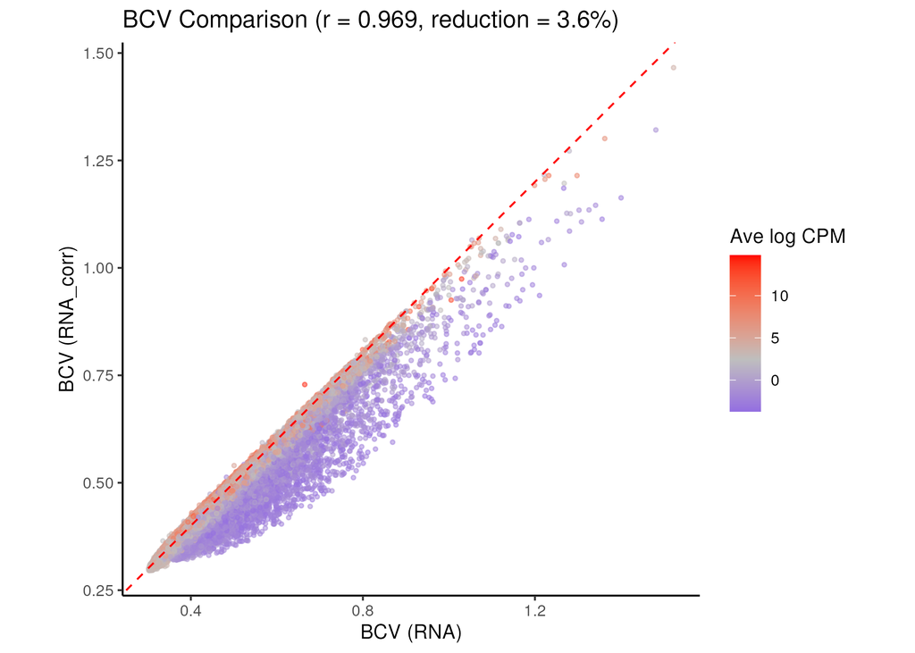

Figure 1

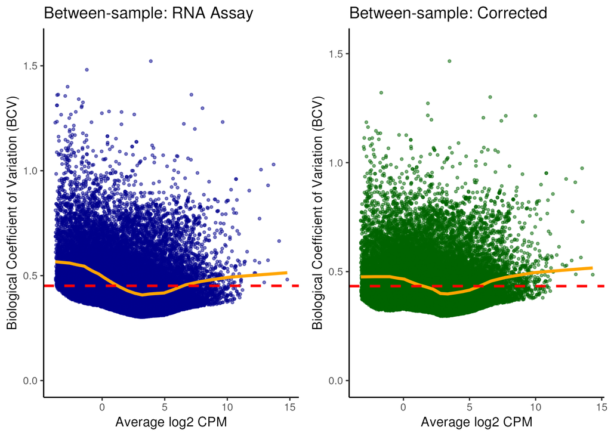

Figure 2

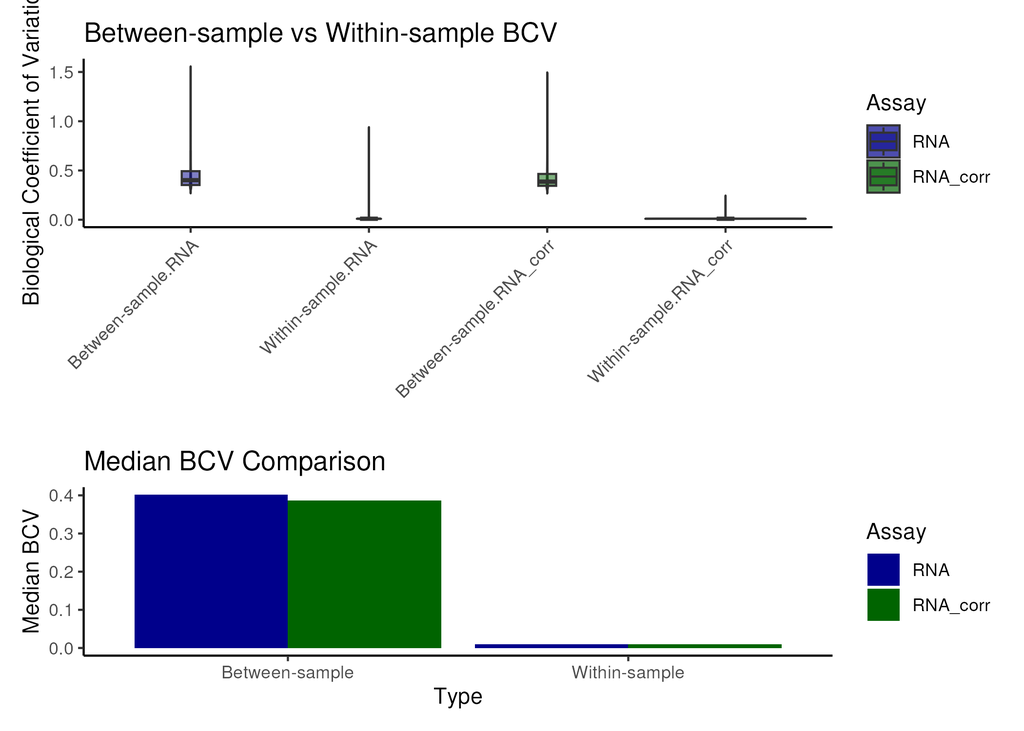

Figure 3

# References

1.

Srivastava, A., Malik, L., Sarkar, H. & Patro, R. [A Bayesian framework for inter-cellular information sharing improves dscRNA-seq quantification](https://doi.org/10.1093/bioinformatics/btaa450). *Bioinformatics* **36**, i292–i299 (2020).

2.

Patro, R., Duggal, G., Love, M. I., Irizarry, R. A. & Kingsford, C. [Salmon provides fast and bias-aware quantification of transcript expression](https://doi.org/10.1038/nmeth.4197). *Nature Methods* **14**, 417–419 (2017).

3.

Srivastava, A., Malik, L., Smith, T., Sudbery, I. & Patro, R. [Alevin efficiently estimates accurate gene abundances from dscRNA-seq data](https://doi.org/10.1186/s13059-019-1670-y). *Genome Biology* **20**, 65 (2019).

4.

Baldoni, P. L. *et al.* [Dividing out quantification uncertainty allows efficient assessment of differential transcript expression with edgeR](https://doi.org/10.1093/nar/gkad1167). *Nucleic Acids Research* **52**, e13–e13 (2024).

5.

Lu-Culligan, A. *et al.* [Maternal respiratory SARS-CoV-2 infection in pregnancy is associated with a robust inflammatory response at the maternal-fetal interface](https://doi.org/10.1016/j.medj.2021.04.016). *Med* **2**, 591–610.e10 (2021).

6.

Bresnahan, S. T. *et al.* Long-read transcriptome assembly reveals vast isoform diversity in the placenta associated with metabolic and endocrine function. *bioRxiv* (2025) doi:10.1101/2025.06.26.661362.